# Part I - Exploratory Analysis of Adult Income Dataset

## Introduction

> The US Adult income dataset is a repository of 48,842 entries extracted from the 1994 US Census database. It contains 15 columns before cleaning. Below are the columns and their meaning:

### The Dataset

- **age:** the age of an individual
- **workclass:** a general term to represent the employment status of an individual
- **fnlwgt:** final weight. In other words, this is the number of people the census believesthe entry represents..
- **education:** the highest level of education achieved by an individual.
- **education-num:** the highest level of education achieved in numerical form.
- **marital-status:** marital status of an individual.
- **occupation:** the general type of occupation of an individual
- **relationship:** represents what this individual is relative to others.
- **race:** Descriptions of an individual’s race
- **sex:** the biological sex of the individual
- **capital-gain:** capital gains for an individual
- **capital-loss:** capital loss for an individual
- **hours-per-week**: the hours an individual has reported to work per week
- **native-country:** country of origin for an individual
- **Salary:** whether or not an individual makes more than $50,000 annually.

```python
# import all packages and set plots to be embedded inline
import numpy as np
import pandas as pd
import matplotlib.pyplot as plt
import seaborn as sb

%matplotlib inline
```

> Load in your dataset and describe its properties through the questions below. Try and motivate your exploration goals through this section.

```python
adult_df = pd.read_csv('adult.data.csv')
adult_df.sample(50)
```

|  | age | workclass | fnlwgt | education | education-num | marital-status | occupation | relationship | race | sex | capital-gain | capital-loss | hours-per-week | native-country | salary |
| --- | --- | --- | --- | --- | --- | --- | --- | --- | --- | --- | --- | --- | --- | --- | --- |
| 31112 | 33 | Private | 226525 | HS-grad | 9 | Divorced | Exec-managerial | Not-in-family | White | Male | 0 | 0 | 60 | United-States | <=50K |
| 28206 | 32 | ? | 377017 | Assoc-acdm | 12 | Never-married | ? | Own-child | White | Male | 0 | 0 | 40 | United-States | <=50K |
| 6114 | 57 | Self-emp-inc | 140319 | HS-grad | 9 | Married-civ-spouse | Adm-clerical | Husband | White | Male | 0 | 0 | 50 | United-States | <=50K |
| 8933 | 76 | Self-emp-not-inc | 237624 | 7th-8th | 4 | Married-civ-spouse | Craft-repair | Husband | White | Male | 0 | 0 | 10 | United-States | <=50K |
| 20942 | 44 | Private | 214415 | Some-college | 10 | Separated | Prof-specialty | Unmarried | Black | Female | 0 | 0 | 40 | United-States | <=50K |
| 27103 | 37 | Private | 222450 | 5th-6th | 3 | Married-civ-spouse | Machine-op-inspct | Husband | White | Male | 0 | 0 | 40 | Mexico | <=50K |
| 17363 | 26 | Private | 169727 | HS-grad | 9 | Married-civ-spouse | Tech-support | Husband | White | Male | 0 | 0 | 40 | United-States | <=50K |
| 13105 | 34 | Private | 260560 | HS-grad | 9 | Married-civ-spouse | Exec-managerial | Husband | White | Male | 0 | 0 | 50 | United-States | <=50K |
| 30267 | 19 | Private | 229431 | Some-college | 10 | Never-married | Prof-specialty | Own-child | White | Male | 0 | 0 | 11 | United-States | <=50K |
| 3661 | 57 | Private | 145189 | Some-college | 10 | Never-married | Adm-clerical | Not-in-family | White | Female | 0 | 0 | 40 | United-States | <=50K |
| 20489 | 51 | Private | 99064 | Assoc-voc | 11 | Married-civ-spouse | Craft-repair | Husband | White | Male | 5013 | 0 | 40 | United-States | <=50K |
| 21486 | 28 | Private | 129882 | Some-college | 10 | Never-married | Adm-clerical | Unmarried | Black | Female | 0 | 0 | 40 | United-States | <=50K |
| 25186 | 63 | ? | 424591 | HS-grad | 9 | Married-civ-spouse | ? | Husband | White | Male | 0 | 0 | 40 | United-States | <=50K |
| 20927 | 25 | Private | 176162 | Bachelors | 13 | Never-married | Handlers-cleaners | Own-child | White | Male | 0 | 0 | 40 | United-States | <=50K |
| 1180 | 50 | ? | 146015 | HS-grad | 9 | Married-civ-spouse | ? | Husband | White | Male | 0 | 0 | 40 | United-States | >50K |
| 9868 | 36 | Private | 32776 | Bachelors | 13 | Married-civ-spouse | Exec-managerial | Husband | White | Male | 0 | 1977 | 40 | United-States | >50K |
| 19590 | 20 | Private | 117476 | Some-college | 10 | Married-civ-spouse | Craft-repair | Husband | White | Male | 0 | 0 | 40 | United-States | <=50K |
| 18807 | 21 | Private | 351381 | HS-grad | 9 | Never-married | Adm-clerical | Own-child | White | Female | 0 | 0 | 40 | United-States | <=50K |
| 8752 | 31 | Local-gov | 158092 | Some-college | 10 | Never-married | Adm-clerical | Own-child | White | Female | 0 | 0 | 35 | United-States | <=50K |
| 20858 | 58 | Private | 234481 | 10th | 6 | Married-civ-spouse | Transport-moving | Husband | White | Male | 0 | 0 | 40 | United-States | <=50K |
| 23 | 43 | Private | 117037 | 11th | 7 | Married-civ-spouse | Transport-moving | Husband | White | Male | 0 | 2042 | 40 | United-States | <=50K |
| 23106 | 54 | Self-emp-inc | 162439 | HS-grad | 9 | Married-civ-spouse | Exec-managerial | Husband | White | Male | 0 | 0 | 98 | United-States | >50K |
| 29840 | 43 | Self-emp-inc | 33729 | Bachelors | 13 | Married-civ-spouse | Sales | Husband | White | Male | 0 | 0 | 45 | United-States | >50K |
| 29831 | 32 | Local-gov | 112650 | HS-grad | 9 | Married-civ-spouse | Protective-serv | Husband | White | Male | 0 | 0 | 40 | United-States | <=50K |
| 10733 | 37 | Private | 208391 | Some-college | 10 | Married-civ-spouse | Transport-moving | Husband | White | Male | 0 | 0 | 40 | United-States | >50K |
| 21805 | 63 | ? | 146196 | Bachelors | 13 | Married-civ-spouse | ? | Husband | White | Male | 0 | 0 | 40 | United-States | <=50K |
| 26228 | 21 | Private | 118401 | Some-college | 10 | Never-married | Other-service | Not-in-family | White | Female | 0 | 0 | 30 | United-States | <=50K |
| 7067 | 28 | Private | 188928 | HS-grad | 9 | Married-civ-spouse | Other-service | Husband | White | Male | 0 | 0 | 40 | United-States | <=50K |
| 17114 | 40 | Private | 174515 | HS-grad | 9 | Widowed | Machine-op-inspct | Unmarried | White | Female | 0 | 0 | 40 | United-States | <=50K |
| 1140 | 19 | Private | 194608 | Some-college | 10 | Never-married | Other-service | Own-child | White | Female | 0 | 0 | 20 | United-States | <=50K |
| 12449 | 35 | Private | 205338 | HS-grad | 9 | Married-civ-spouse | Craft-repair | Husband | White | Male | 0 | 0 | 40 | United-States | <=50K |
| 11139 | 35 | Private | 167062 | HS-grad | 9 | Married-civ-spouse | Adm-clerical | Husband | White | Male | 0 | 0 | 40 | United-States | <=50K |
| 30609 | 42 | Private | 153414 | Bachelors | 13 | Married-civ-spouse | Sales | Husband | Black | Male | 0 | 0 | 40 | United-States | >50K |
| 4130 | 24 | Private | 238917 | 5th-6th | 3 | Never-married | Craft-repair | Unmarried | White | Male | 0 | 0 | 40 | El-Salvador | <=50K |
| 7668 | 23 | Private | 160398 | Some-college | 10 | Married-spouse-absent | Handlers-cleaners | Unmarried | White | Male | 0 | 0 | 40 | United-States | <=50K |
| 17019 | 24 | Private | 187717 | Bachelors | 13 | Never-married | Adm-clerical | Own-child | White | Female | 0 | 0 | 40 | United-States | <=50K |
| 26497 | 25 | Private | 193051 | Bachelors | 13 | Married-civ-spouse | Tech-support | Husband | White | Male | 0 | 0 | 35 | United-States | <=50K |
| 4061 | 28 | Private | 210867 | 11th | 7 | Divorced | Sales | Own-child | White | Male | 0 | 0 | 40 | United-States | <=50K |
| 30583 | 20 | Private | 165097 | HS-grad | 9 | Never-married | Craft-repair | Not-in-family | White | Male | 0 | 0 | 40 | United-States | <=50K |
| 30308 | 35 | Private | 216256 | Assoc-voc | 11 | Never-married | Other-service | Not-in-family | White | Male | 0 | 0 | 60 | United-States | <=50K |
| 2690 | 61 | Private | 197286 | 9th | 5 | Married-civ-spouse | Craft-repair | Husband | White | Male | 0 | 0 | 40 | United-States | <=50K |
| 8514 | 21 | Private | 107882 | Assoc-acdm | 12 | Never-married | Other-service | Own-child | White | Female | 0 | 0 | 9 | United-States | <=50K |
| 29818 | 24 | Private | 196742 | HS-grad | 9 | Divorced | Other-service | Unmarried | White | Female | 0 | 0 | 40 | United-States | <=50K |
| 18710 | 49 | Private | 233639 | 11th | 7 | Married-civ-spouse | Other-service | Husband | White | Male | 0 | 0 | 50 | United-States | <=50K |
| 20293 | 47 | Private | 249935 | 11th | 7 | Divorced | Craft-repair | Own-child | White | Male | 0 | 0 | 8 | United-States | <=50K |
| 23205 | 29 | State-gov | 240738 | HS-grad | 9 | Married-civ-spouse | Craft-repair | Husband | White | Male | 0 | 0 | 40 | United-States | >50K |
| 14964 | 23 | Private | 413345 | Bachelors | 13 | Never-married | Adm-clerical | Not-in-family | White | Female | 0 | 0 | 60 | United-States | <=50K |
| 28931 | 24 | Private | 34506 | HS-grad | 9 | Never-married | Machine-op-inspct | Unmarried | White | Female | 0 | 0 | 40 | United-States | <=50K |
| 15812 | 38 | Private | 266325 | Bachelors | 13 | Married-civ-spouse | Prof-specialty | Wife | White | Female | 0 | 0 | 32 | United-States | >50K |
| 13462 | 55 | Self-emp-not-inc | 111625 | HS-grad | 9 | Married-civ-spouse | Sales | Husband | White | Male | 0 | 0 | 40 | United-States | <=50K |

```python
# this is an overview of the data shape and composition
print(adult_df.shape)
print(adult_df.dtypes)
print(adult_df.info())
```

```
(32561, 15)
age                int64
workclass         object
fnlwgt             int64
education         object
education-num      int64
marital-status    object
occupation        object
relationship      object
race              object
sex               object
capital-gain       int64
capital-loss       int64
hours-per-week     int64
native-country    object
salary            object
dtype: object
<class 'pandas.core.frame.DataFrame'>
RangeIndex: 32561 entries, 0 to 32560
Data columns (total 15 columns):
age               32561 non-null int64
workclass         32561 non-null object
fnlwgt            32561 non-null int64
education         32561 non-null object
education-num     32561 non-null int64
marital-status    32561 non-null object
occupation        32561 non-null object
relationship      32561 non-null object
race              32561 non-null object
sex               32561 non-null object
capital-gain      32561 non-null int64
capital-loss      32561 non-null int64
hours-per-week    32561 non-null int64
native-country    32561 non-null object
salary            32561 non-null object
dtypes: int64(6), object(9)
memory usage: 3.7+ MB
None
```

```python
# making a copy of the dataframe before cleaning and analysis
df = adult_df.copy()
```

### Data cleaning

- Unnecessary columns have to be removed from the dataset
- I discovered that some cells have '?' as their values, they should all be changed to NAN
- I need to create a new column `age_group` to store age groups

#### Issue 1:

Removing unnecessary columns from the dataframe

```python
# subseting for the columns needed for this ananlysis
df = df[['age','workclass','education','marital-status', 'occupation', 'relationship',
         'race', 'sex', 'hours-per-week', 'native-country','salary']]
df.head(1)
```

|  | age | workclass | education | marital-status | occupation | relationship | race | sex | hours-per-week | native-country | salary |
| --- | --- | --- | --- | --- | --- | --- | --- | --- | --- | --- | --- |
| 0 | 39 | State-gov | Bachelors | Never-married | Adm-clerical | Not-in-family | White | Male | 40 | United-States | <=50K |

#### Issue 1:

changing '?' values to NAN

```python
#solution:
df = df.replace('?', np.nan)
df.head(5)
```

|  | age | workclass | education | marital-status | occupation | relationship | race | sex | hours-per-week | native-country | salary |
| --- | --- | --- | --- | --- | --- | --- | --- | --- | --- | --- | --- |
| 0 | 39 | State-gov | Bachelors | Never-married | Adm-clerical | Not-in-family | White | Male | 40 | United-States | <=50K |
| 1 | 50 | Self-emp-not-inc | Bachelors | Married-civ-spouse | Exec-managerial | Husband | White | Male | 13 | United-States | <=50K |
| 2 | 38 | Private | HS-grad | Divorced | Handlers-cleaners | Not-in-family | White | Male | 40 | United-States | <=50K |
| 3 | 53 | Private | 11th | Married-civ-spouse | Handlers-cleaners | Husband | Black | Male | 40 | United-States | <=50K |
| 4 | 28 | Private | Bachelors | Married-civ-spouse | Prof-specialty | Wife | Black | Female | 40 | Cuba | <=50K |

#### Issue 2:

Create new column `age_group`

```python
#create an age group to avoid noisy and clustered visuals
ages = df.age
age_group = []
for i, age in ages.items():

    if age <= 20:
        age_group.append('17-20')
    elif age>20 and age<31:
        age_group.append('21-30')
    elif age>30 and age<41:
        age_group.append('31-40')
    elif age>40 and age<51:
        age_group.append('41-50')
    elif age>50 and age<61:
        age_group.append('51-60')
    elif age>60 and age<71:
        age_group.append('61-70')
    elif age>70 and age<81:
        age_group.append('71-80')
    else:
        age_group.append('above 80')
df['age_group']= age_group


# this method can also be used
"""
conditions = [
    (df['age']<=20),
    (df['age']>20) & (df['age']<31),
    (df['age']>30) & (df['age']<41),
    (df['age']>40) & (df['age']<51),
    (df['age']>50) & (df['age']<61),
    (df['age']>60) & (df['age']<71),
    (df['age']>70) & (df['age']<81),
    (df['age']>80),
    ]

# create a list of the values we want to assign for each condition
values = ['17-20', '21-30', '31-40', '41-50', '51-60', '61-70', '71-80', 'above 80']

# create a new column and use np.select to assign values to it using our lists as arguments
df['age_group'] = np.select(conditions, values)



# display updated DataFrame
df.head()
"""
```

[output not shown]

### What is/are the main feature(s) of interest in your dataset?

> The main porpose of this analysis is to find the distribution of salary in the US and how it is affected by different factors such as age, race, education etc.

### What features in the dataset do you think will help support your investigation into your feature(s) of interest?

> What my investigation is looking for is how different factors (columns) such as education, marital-status, native country make people make less than 50k usd or more

## Univariate Exploration

> In this section, I will investigate distributions of individual variables. If I see unusual points or outliers, I will take a deeper look to clean things up and prepare myself to look at relationships between variables.

### Question 1:

what percentage of people earn above and below 50k usd

### visualization :

```python
# getting the distribution by salary group
sal_dist= df['salary'].value_counts().reset_index()
(list(sal_dist['index']))
```

```
['<=50K', '>50K']
```

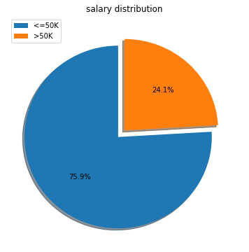

```python
#plotting a pie since we only have 2 variables

#creating a function for the pie
def pie_1(data, title, explode,legend, fig_x =6, fig_y=6, shadow = False, startangle =90,autopct ='%1.1f%%'):
    plt.figure(figsize=[fig_x, fig_y])

    plt.pie(data, explode = explode, autopct=autopct ,shadow=shadow, startangle=startangle)
    plt.title(title)
    plt.legend(legend)

#calling the function
pie_1(list(sal_dist['salary']),title = 'salary distribution' ,fig_x =6, fig_y=6,
      explode =[0.1,0], shadow = True, legend = (list(sal_dist['index'])));
```

### observations:

I can observe that about 76% of the people earn 50k and below while 24% earn above 50k

### Question 2:

Which race do these people belong to

### Visualization:

```python
# grouping by race
top_10 = df['race'].value_counts()
top_10
```

```
White                 27816
Black                  3124
Asian-Pac-Islander     1039
Amer-Indian-Eskimo      311
Other                   271
Name: race, dtype: int64
```

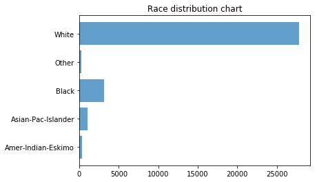

```python
#plotting a horizontal barchart
plt.barh(top_10.index, top_10.values, alpha=0.7)
plt.title('Race distribution chart');
```

### obsevation:

White people are by far more represented in the dataset, a distant second is black people

### Question 3:

For how long do people work in a week?

### Visualization:

```python
hours = df['hours-per-week'].value_counts()
hours.head(4)
```

```
40    15217
50     2819
45     1824
60     1475
Name: hours-per-week, dtype: int64
```

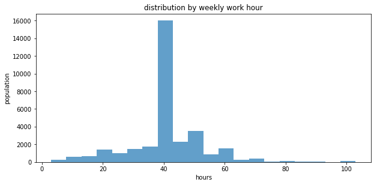

```python
def hist_1(df_i, col, x_label, y_label, title, sub_x=1, sub_y=2, sub_z=1, fig_x =6, fig_y=15, alpha = 0, start_bins = 0.0):
    plt.figure(figsize=[fig_x, fig_y])
    plt.subplot(sub_x, sub_y, sub_z)

    bins = np.arange(start_bins, df[col].max()+5.5, 5)
    plt.hist(data = df_i, x = col, bins=bins, alpha = alpha)
    plt.xlabel(x_label)
    plt.ylabel(y_label)
    plt.title(title)

hist_1(df_i=df, col='hours-per-week', x_label = 'hours', y_label = 'population', title = 'distribution by weekly work hour',
       alpha = 0.7, start_bins = 03.0,fig_x=10, fig_y=10,sub_x=2, sub_y=1, sub_z=1)
```

### obsevation:

Most people work the standard 40hrs per week (15,000 people), about 3000 people work 50 hrs every week

### Question 4 :

What is the distribution of education level

### Visualization:

```python
edu = df['education'].value_counts()
edu
```

```
HS-grad         10501
Some-college     7291
Bachelors        5355
Masters          1723
Assoc-voc        1382
11th             1175
Assoc-acdm       1067
10th              933
7th-8th           646
Prof-school       576
9th               514
12th              433
Doctorate         413
5th-6th           333
1st-4th           168
Preschool          51
Name: education, dtype: int64
```

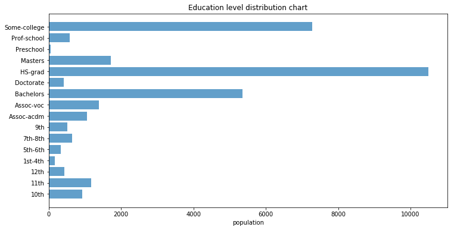

```python
#plotting a horizontal barchart
plt.figure(figsize = [12,6])
plt.barh(edu.index, edu.values, alpha=0.7)
plt.title('Education level distribution chart')
plt.xlabel('population');
```

### obsevation:

majority of them have either a some-college, high school or bachelors degree certificates, very few have preschool

### Question 5:

What is the age distribution amongst the people?

### Visualization:

```python
ages = df['age'].value_counts()
ages.head(2)
```

```
36    898
31    888
Name: age, dtype: int64
```

```python
ages1 = df.age_group.value_counts().sort_values(ascending =False)
ages1
```

```
31-40       8546
21-30       8162
41-50       6983
51-60       4128
17-20       2410
61-70       1792
71-80        441
above 80      99
Name: age_group, dtype: int64
```

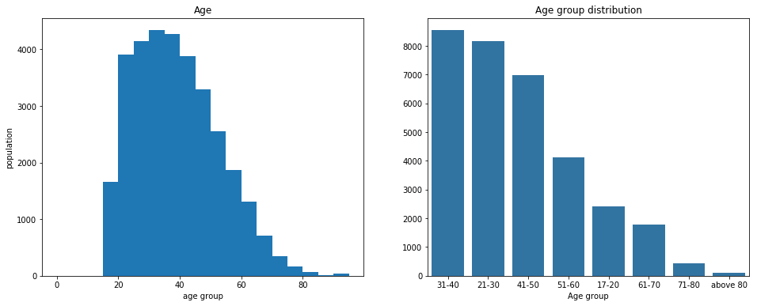

```python
hist_1(df_i=df, col='age', x_label = 'age group', y_label = 'population', title = 'Age',
       alpha = 1,fig_x=16, fig_y=6, sub_x=1, sub_y=2, sub_z=1)

plt.subplot(1,2,2)
base_color = sb.color_palette()[0]
sb.barplot( ages1.index, ages1.values, color= base_color)
plt.xlabel('Age group')
plt.title('Age group distribution');
```

### obsevation:

The age distribution is right skewed and the most frequent age group falls between 21 and 50 years

### Question 6:

What is the population distribution by country of origin

### Visualization:

```python
country = df['native-country'].value_counts()
country
```

```
United-States                 29170
Mexico                          643
Philippines                     198
Germany                         137
Canada                          121
Puerto-Rico                     114
El-Salvador                     106
India                           100
Cuba                             95
England                          90
Jamaica                          81
South                            80
China                            75
Italy                            73
Dominican-Republic               70
Vietnam                          67
Guatemala                        64
Japan                            62
Poland                           60
Columbia                         59
Taiwan                           51
Haiti                            44
Iran                             43
Portugal                         37
Nicaragua                        34
Peru                             31
Greece                           29
France                           29
Ecuador                          28
Ireland                          24
Hong                             20
Trinadad&Tobago                  19
Cambodia                         19
Laos                             18
Thailand                         18
Yugoslavia                       16
Outlying-US(Guam-USVI-etc)       14
Hungary                          13
Honduras                         13
Scotland                         12
Holand-Netherlands                1
Name: native-country, dtype: int64
```

```python
US = country.values[0]
others= country.values[1:].sum()
```

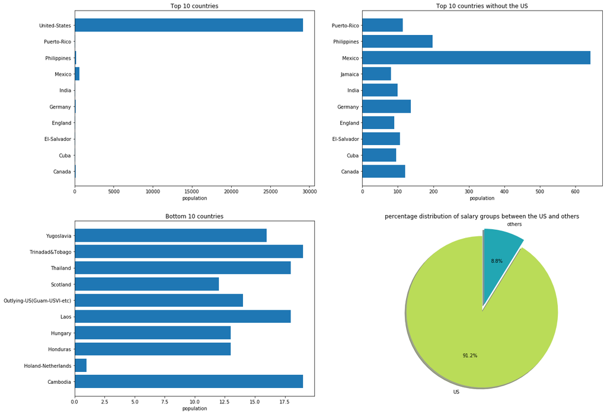

```python
#define size of figure
plt.figure(figsize=[20,15])

#subplots
plt.subplot(2,2,1)
plt.barh(country.index[:10],country.values[:10])
plt.title('Top 10 countries')
plt.xlabel('population')

plt.subplot(2,2,2)
plt.barh(country.index[1:11],country.values[1:11])
plt.title('Top 10 countries without the US')
plt.xlabel('population');

plt.subplot(2,2,3)
plt.barh(country.index[-10:],country.values[-10:])
plt.title('Bottom 10 countries')
plt.xlabel('population');

plt.subplot(2,2,4)
explode = [0.1, 0]
label = ['US','others']
#fig = plt.figure(figsize =(6, 6))
plt.pie([US,others], labels = label, explode = explode, autopct='%1.1f%%',shadow=True, startangle=90, colors = ( "#BADC58", "#22A6B3"))
plt.title('percentage distribution of salary groups between the US and others' )
plt.axis('equal');
```

### obsevation:

- Most of the population (91%) are from the US, that's understandable because the census was carried out in the US
- About 9% is shared amongst the remaining countries with Mexico on top, maybe because of it's proximity to the US
- The netherlands has the least experts working in the US

### Discuss the distribution(s) of your variable(s) of interest. Were there any unusual points? Did you need to perform any transformations?

I am mostly interested in the `salary` distribution, We can observe that about 76% of the people earn 50k and below while only 24% earn above 50k. We shall analyze further to unravel the factors that affect `salary`

## Bivariate Exploration

> In this section, I shall investigate relationships between pairs of variables in data.I will Make sure the variables that I cover here have been introduced in some fashion in the previous section (univariate exploration).

### Question 7:

What is the relationship between age and salary

### Visualization:

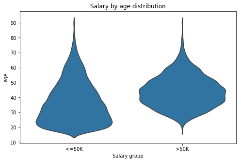

```python
plt.figure(figsize=[8,5])
base_color = sb.color_palette()[0]
sb.violinplot(data=df,x='salary', y ='age', color=base_color, inner =None)
plt.title('Salary by age distribution')
plt.xlabel('Salary group');
```

### obsevation:

I can observe that people between 20 and 30 are more likely to earn 50k and below, while people between 31 and 60 are more likely to earn above 50k

### Question 8:

How does gender affect salary?

### Visualization:

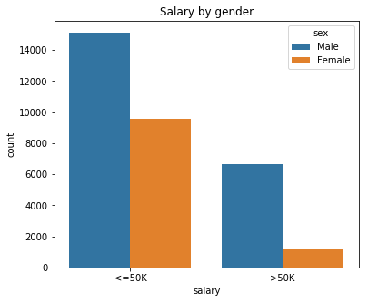

```python
plt.figure(figsize= [6,5])
sb.countplot(data = df, x = 'salary', hue = 'sex')
plt.title('Salary by gender');
```

### obsevation:

- There are more male folks in the Dataset.
- Secondly, male folks are more likely to earn above 50k than the female folk

### Question 9 - 11:

How do `education`, `age_group` and `race` affect `salary`?

### Visualization:

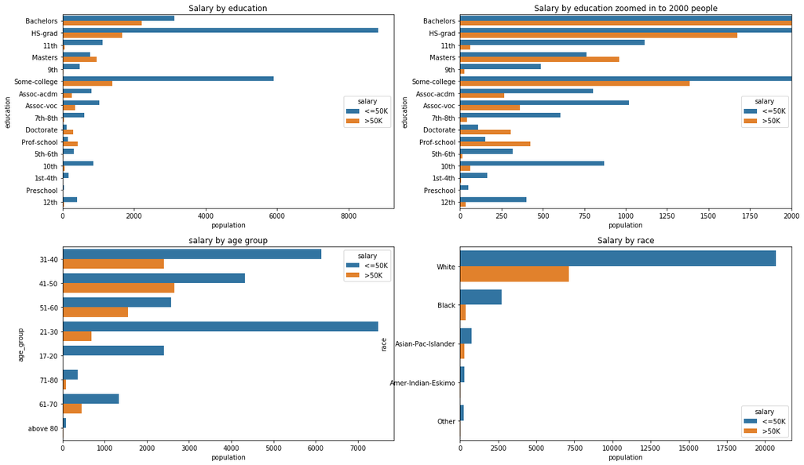

```python
plt.figure(figsize =[20,12])

plt.subplot(2,2,1)
sb.countplot(data=df, y='education', hue='salary')
plt.title('Salary by education')
plt.xlabel('population')

plt.subplot(2,2,3)
sb.countplot(data = df, y = 'age_group', hue = 'salary')
plt.title('salary by age group')
plt.xlabel('population')

plt.subplot(2,2,4)
sb.countplot(data = df, y = 'race', hue = 'salary')
plt.title('Salary by race')
plt.xlabel('population')

plt.subplot(2,2,2)
sb.countplot(data = df, y = 'education', hue = 'salary')
plt.xlim(0,2000)
plt.title('Salary by education zoomed in to 2000 people')
plt.xlabel('population');
```

### obsevation:

- people who have a `Bachelors`, `Masters`, `Doctorate` degrees and professors have high `>50k` / `>=50` ratio
- There are more white folks in the Dataset. Secondly, white folks are more likely to earn above 50k than other races.
- people above 31 and below 71 are more likely to earn above 50k however, people above 60 years are few in the dataset

### Question 12:

How does `relationship` affect `salary`

### Visualization:

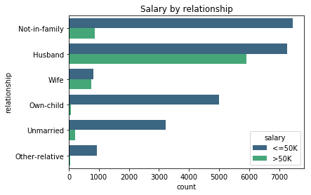

```python
sb.countplot(data=df, y='relationship', hue='salary',palette='viridis')
plt.title('Salary by relationship');
```

### obsevation:

I observed that married people are more likely to earn high wages than other groups

### Talk about some of the relationships you observed in this part of the investigation. How did the feature(s) of interest vary with other features in the dataset?

I discovered that these people are more likely to earn high salary:

- People that have a degree
- white people
- married people
- people over 35 and below 50
- people who are men etc.

### Did you observe any interesting relationships between the other features (not the main feature(s) of interest)?

No, there is no relationship

## Multivariate Exploration

> Create plots of three or more variables to investigate your data even further. Make sure that your investigations are justified, and follow from your work in the previous sections.

### Question 13:

How does `age` and `workclass` affect `salary`?

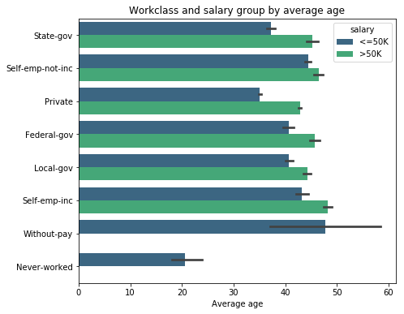

```python
plt.figure(figsize=[7,6])
sb.barplot(data = df, y = 'workclass', x = 'age', hue = 'salary',palette= 'viridis' )
plt.ylabel('')
plt.xlabel('Average age')
plt.title('Workclass and salary group by average age');
```

### conclusion:

Apart from `never-worked` and `without-pay` groups, people that earned above 50k in other groups are generally older than people that earned less, also people that have never worked are mostly the young ones with an average age of about 20 years

### Question 14:

what is the relationship between `salary`, `age`and `sex`

### Visualization:

```
''
```

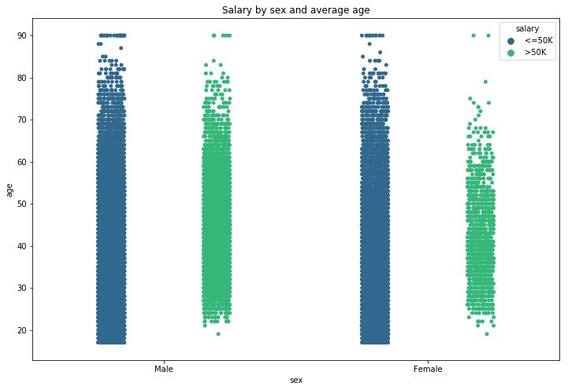

```python
plt.figure(figsize=(12,8))

sb.stripplot(x='sex', y='age', data=df, jitter=True, hue='salary', dodge=True, palette='viridis')
plt.title('Salary by sex and average age')
;
```

```python
df.groupby(['sex','salary'])['age'].value_counts()
```

```
sex     salary  age
Female  <=50K   20     363
                23     357
                19     355
                22     338
                21     327
                25     298
                24     297
                28     280
                26     276
                27     273
                18     268
                31     248
                36     245
                30     244
```

[output cut: 48 more lines]

### Question 5:

How does education and duration of work per week affect salary?

### Visualization:

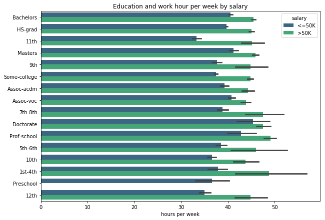

```python
plt.figure(figsize=[10,7])
sb.barplot(data = df, y = 'education', x = 'hours-per-week', hue = 'salary',palette= 'viridis' )
plt.ylabel('')
plt.xlabel('hours per week')
plt.title('Education and work hour per week by salary');
```

### obsevation:

I cannot see any pattern or correlation between education level and how long people worked, the only take away is that people that earn above 50k generally work for longer hours

## Conclusions

I would conclude by saying that you are more likely to earn above 50k in the US if you are:

- a man
- married
- have atleast a bachelors degree
- a white person (don't think it has to do with racism)
- between the ages of 30 and 60 with 40 being the best age
- working long hours